# act_report

This is a blog post about dogs. More specifically about the twitter sensation "WeRateDogs". The account that posts pictures of cute dogs with their unconventional rating system and hilarious comments. What's better than having a twitter feed full of pictures of cute puppers.This post tries to understand dog posts and people's reactions.

[figure not shown]

- After gathering data from the account's archive, data from an image prediction neural network and data from the twitter API "Tweepy", Assessing the data and forming a comprehensive DataFrame, Let's explore the data together to find some intresting answers.
- Let's try to find out how this phenomenon began. By asking the question how many retweets and favorites per unit time?

```python
# creating a DataFrame with "timestamp" column as the index
df_timestamp = pd.read_csv('twitter_archive_master.csv', index_col = 'timestamp', parse_dates = True)
df_timestamp.head(2)
```

| timestamp | tweet_id | text | expanded_urls | rating_numerator | rating_denominator | name | dog_stage | retweet_count | favorite_count | jpg_url | img_num | p1 | p1_conf | p1_dog | p2 | p2_conf | p2_dog | p3 | p3_conf | p3_dog |
| --- | --- | --- | --- | --- | --- | --- | --- | --- | --- | --- | --- | --- | --- | --- | --- | --- | --- | --- | --- | --- |
| 2017-08-01 00:17:27+00:00 | 892177421306343426 | This is Tilly. She's just checking pup on you.... | https://twitter.com/dog_rates/status/892177421... | 13 | 10 | Tilly | NaN | 6514 | 33819 | https://pbs.twimg.com/media/DGGmoV4XsAAUL6n.jpg | 1.0 | Chihuahua | 0.323581 | True | Pekinese | 0.090647 | True | papillon | 0.068957 | True |
| 2017-07-31 00:18:03+00:00 | 891815181378084864 | This is Archie. He is a rare Norwegian Pouncin... | https://twitter.com/dog_rates/status/891815181... | 12 | 10 | Archie | NaN | 4328 | 25461 | https://pbs.twimg.com/media/DGBdLU1WsAANxJ9.jpg | 1.0 | Chihuahua | 0.716012 | True | malamute | 0.078253 | True | kelpie | 0.031379 | True |

```python
retweets = df_timestamp.retweet_count.resample('M').mean()
favorites = df_timestamp.favorite_count.resample('M').mean()
```

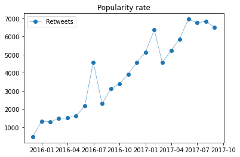

```python
fig, ax = plt.subplots() # creating a figure with one axis
ax.set_title('Popularity rate')
ax.plot(retweets,marker='o', linestyle='-', linewidth=0.5, label='Retweets')
ax.legend();
```

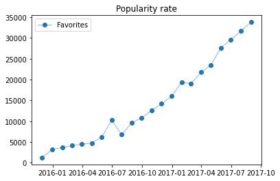

```python
fig, ax = plt.subplots() # creating a figure with one axis
ax.set_title('Popularity rate')
ax.plot(favorites,marker='o', linestyle='-', linewidth=0.5, label='Favorites')
ax.legend();
```

- Noticed the slight difference in overall trend between number of tweets against number of favorites.
- the number of favorites graph is close to a linear relationship hinting to a steady increase in popularity.
- Let's ask ourselves what is the reason behind this popularity? Was it because there was an increase in the number of tweets per month ? Is it the quantity or the quality of tweets that make people come back for more?
- Approaching the solution should begin by counting the number of tweets per unit time, I chose the unit time to be monthly assuming it would be most convenient.

```python
number_of_tweets_per_month = []
for sample in (df_timestamp.retweet_count.resample('M')):
    number_of_tweets_per_month.append(len(np.array(sample[1])))
```

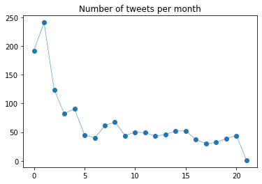

```python
fig, ax = plt.subplots() # creating a figure with one axis
ax.set_title('Number of tweets per month')
ax.plot(number_of_tweets_per_month,marker='o', linestyle='-', linewidth=0.5,);
```

- Clearly the answer is no. Which probably means that the quality -not the number- of tweets is the reason behind the popularity.

##### Now let's take a different approach

##### What is the most tweeted about dog breed by the account "WeRateDogs"?

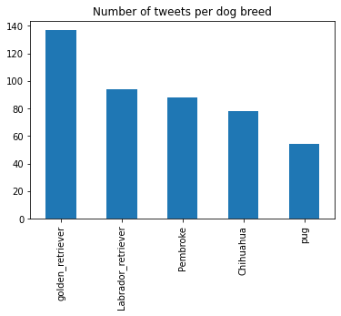

```python
fig, ax = plt.subplots()
df.p1.value_counts()[0:5].plot(kind='bar')
ax.set_title('Number of tweets per dog breed');
```

##### And the winner is Golden retriever, congratulations!

[figure not shown]

The Golden Retriever is a medium-large gun dog that was bred to retrieve shot waterfowl, such as ducks and upland game birds, during hunting and shooting parties.The name "retriever" refers to the breed's ability to retrieve shot game undamaged due to their soft mouth. Golden retrievers have an instinctive love of water, and are easy to train to basic or advanced obedience standards.

### What is the most popular dog breed?

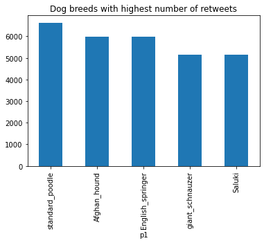

```python
fig, ax = plt.subplots()
df.groupby(['p1']).retweet_count.mean().sort_values(ascending=False)[0:5].plot(kind='bar')
ax.set_title('Dog breeds with highest number of retweets');
```

##### Congratulations for all the Standard poodle dogs

[figure not shown]

Ranked second most intelligent dog breed just behind the Border Collie, the poodle is skillful in many dog sports and activities, including agility, obedience, tracking, herding, circus performance, and assistance dogs. Poodles have taken top honors in many conformation shows, including "Best in Show" at the Westminster Kennel Club Dog Show in 1991, 2002, and 2020 and at the World Dog Show in 2007 and 2010. They are recorded as the seventh most popular dog breed in the United States.